# JuliaとQuartoを使ってレポートを書く 1

マクロ経済学IV 2026

Author

Affiliation

Hirotaka Fukui

Kobe University, Graduate School of Economics

Published

2026年10月5日

# はじめに

## TAセッション1&2の目的

第1回と第2回のTAセッションではJuliaとQuartoを用いて レポート課題を完成させるために必要なスキルと知識を身につけることを目的とします。

**主な目標**

- .qmd（Quarto Markdown）ファイルの構造とワークフローを理解すること。
- .qmdファイルを執筆し、整ったPDFレポートとして出力・提出できるようにすること。
- Juliaの基本的な文法、データ処理、可視化に慣れ、再現可能なドキュメント内で活用できるようにすること。

## セッション内容

**TAセッション1**

- 計算プロセスの理解：ソースコードから実行、メモリ管理、出力生成までの流れを学ぶ。
- Quartoの導入：ドキュメント構造、YAMLヘッダー、レンダリング設定の基礎を理解する。
- Juliaコードチャンクの記述方法と、結果（図・表・計算結果）の埋め込み方を学ぶ。

**TAセッション2**

- プロジェクト構成とファイルパスの管理方法を学ぶ。
- Juliaの基本プログラミング：配列、データフレーム、グラフ描画の操作。
- .qmdファイルをPDFにレンダリングし、コンパイルエラーを解決する方法を習得する。

## 事前準備

TAセッションに参加する前に、以下のソフトウェアを各自のPCにインストールしておいてください。

- **Visual Studio Code (VS Code)**：コード編集およびQuartoドキュメント作成用エディタ
- **Quarto**：レポートをPDFやHTMLにレンダリングするためのドキュメントツール
- **Julia**：プログラミング言語（数値計算・データ分析・可視化に使用）

## 課題解説セッションの方針

みなさんに「数値計算」によるマクロ経済分析を理解してもらえるように問題の解答だけでなく

- 理論モデルの理解
- 数値解法の理解
- プログラミングの理解

を最終的なゴールとしていこうと思っています。

# プログラミング

## プログラミングとは何か

プログラミングは簡単に言うと

> コンピュータに実行させる処理の順番を示す**プログラム**を「人間が理解できる言葉」で書く

ことです。つまり「こういうことをしてください」とコンピュータに命令する命令書を書くことです。

## プログラミングとは何か

[マクロIVでのテンプレート](https://github.com/kazuyanagimoto/course-kobe-macro4-2025/blob/main/assignment/00-answer.qmd)

の`{julia}`と書かれているところのコードを見ると`plot`や`for`など、英語で書かれている部分があることがわかります。

これが人間が読める言葉で書かれているPCへの**命令書**です。

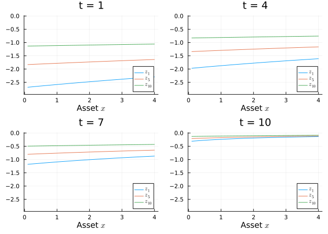

Figure 5.1: Value function for different values of $z$.

実行するとプロットが出てきます。このプロットを作成するために

```
for ....

end

plot...
```

という命令書を人間が書きます。

それを**実行**することでコンピュータ側はそれを自分たちが理解できる0と1の羅列に落とし込んでいき、内部で演算処理をして最終的に画面にプロットを表示してくれているわけです。

## Julia、Quarto、VSCodeの役割

- **Julia**というプログラミング言語を使ってその命令書を書いていきます。
- **Quarto**にそのコードを埋め込むことできれいなレポートを作ることができます。
- **VSCode**はその2つを動かす土台です。

## プログラミングのコツ

- 何をするのかの**ワークフロー**を一旦書いてみる。

[マクロIVでのテンプレート](https://github.com/kazuyanagimoto/course-kobe-macro4-2025/blob/main/assignment/00-answer.qmd)の例だと

1. パラメータや最小・最大値、結果の格納庫を作る。
2. 効用関数を定義する。
3. 反復命令のコードを作る。価値関数の初期値を定義し、グリッドの数だけfor文を使って価値関数を反復計算させる。
4. Technology shock $z$ で総和をとることで期待値を計算する。

…

最初に何をするのかをあらかじめ書いておくことをお勧めします。自分の頭で手順がはっきりしていないものをプログラミングするのは難しいです。

## PCの「頭の良さ」を過大評価しない。

- PCは正直言うと電卓のでかい版なので、そんなに大したことはできません(でも工夫することで難しい計算をしてくれます)。
- きちんと命令書を書いてあげないとうまく動いてくれません。
- うまく動かないときは命令書がPCにとってわかりにくいことが問題です。
- JuliaならJuliaの、QuartoならQuartoの「書き方のルール」があります。それをしっかりと守りましょう。

# Quarto入門

## Quartoとは?

- Quartoはコードとその結果、そして文章を一つの文書としてまとめてくれるものです
- Julia, R, Pythonなどのコードを書いて実行することができます

## Quartoの構造

Quartoで作成された文書`.qmd`のソースコードは大きく次の3つの領域に分けられます

1. YAMLヘッダー
2. コードチャンク
3. テキスト

## Quartoの構造: YAMLヘッダー

YAMLヘッダーは

- 文書のタイトル、著者、作成日などのメタ情報
- 文書全体のフォーマットやスタイルを指定する情報

を文書の最初に指定するものです。YAMLヘッダーは `---`と`---`の間に書く必要があります。

## Quartoの構造: YAMLヘッダー

課題レポートの例

```
---
title: "Exercise 0: Life Cycle Model"
date: today
date-format: "YYYY年M月D日"
author: YOUR NAME
execute:
  echo: false
  warning: false
  message: false
format: typst
engine: julia #knitr for R, jupyter for Python
brand:
  typography:
    fonts:
      - family: Noto Serif JP
        source: google
      - family: IBM Plex Sans JP
        source: google
    base: Noto Serif JP
    headings:
      family: IBM Plex Sans JP
      weight: regular
number-sections: true
---
```

YAMLヘッダーの以下の部分でタイトル、日付、著者の情報を記述しています。

```
title: "Exercise 0: Life Cycle Model"
date: today
date-format: "YYYY年M月D日"
author: YOUR NAME
```

```
execute:
  echo: false
  warning: false
  message: false
format: typst
engine: julia #knitr for R, jupyter for Python
```

この部分でコードチャンクの設定や出力(typst)の設定をしています。

```
brand:
  typography:
    fonts:
      - family: Noto Serif JP
        source: google
      - family: IBM Plex Sans JP
        source: google
    base: Noto Serif JP
    headings:
      family: IBM Plex Sans JP
      weight: regular
number-sections: true
```

この部分で文書全体のフォーマット設定をしています。

**Important**

課題レポートでは**レポートの解答テンプレート**の YAMLヘッダーをコピペすることを推奨します。 変更する部分は

```
title: "Exercise 0: Life Cycle Model"

author: YOUR NAME
```

この2つだけにしておくことを推奨します。

## Quartoの構造: コードチャンク

コードチャンクは**Julia**やほかの言語のコードが入る領域で、コンパイルするとコードとその実行結果が表示されます。

`` ``` `` (バックスラッシュ3つ)のあとに中括弧{}をいれ、中括弧の中に使いたい言語の名前を書きます。コードの終わりは再びバックスラッシュ3つを入れます。

Juliaの場合は `` ```{julia} ``と`` ``` ``の間にコードを書きます。

### 例

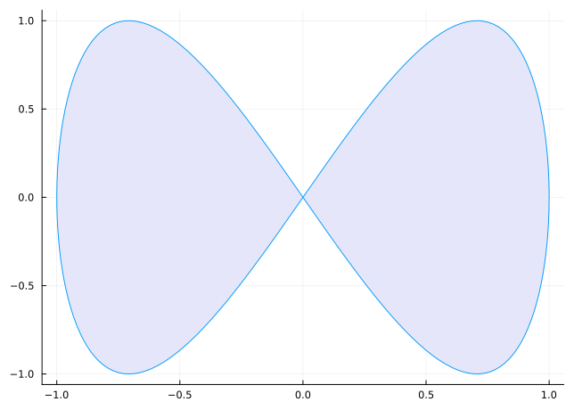

```julia
plot(sin,
     x->sin(2x),
     0,
     2π,
     leg=false,
     fill=(0,:lavender))
```

コードチャンクの先頭にオプションをつけることができます。主なものに

```
#| echo: false
#| message: false
#| warning: false
#| include: false
```

があります。それぞれの意味は以下の通りです。

`echo: false`: コードを本文に表示しない（実行はする）。

`message: false`: パッケージ読み込み時など、実行時の “message” を本文に表示させない。

`warning: false`: エラーなどの警告（warnings）を本文に表示させない。

`include: false`: チャンクそのものを「文書に含めない」。パッケージ読み込みなど、裏方処理用につかう。

`true`で逆になります。デフォルトは`true`です。

## Quartoの構造: テキスト

Quartoでは文章を「Markdown」という形式にのっとって書いていきます。レポートを作るだけなら平文の書き方、見出しのつけ方、数式の書き方がわかっていれば十分です。

### 平文

```
あのイーハトーヴォのすきとおった風、夏でも底に冷たさをもつ青いそら、うつくしい森で飾られたモリーオ市、郊外のぎらぎらひかる草の波。
```

### 見出し

`#`を使って全部で6段階の見出しをつけることができます。`#`のあとにはスペースを入れてつけたい見出しを書きます。`#`はかなりでかいのでレポートの見出しは`##`くらいがいいと思います。

```
# １番大きい

## 2番目に大きい

### 3番目に...

#### 4番目に...

##### 5番目に...

###### 1番小さい
```

### 数式を入力する

数式を入力するときは`$`を使います。数式の書き方は基本的にTeXと同じです。

**行内数式（inline math）**

文の途中に数式を入れるときは `$...$` で囲みます。

```
生産関数は $Y = A K^\alpha L^{1-\alpha}$ で表される。
```

生産関数は $Y = A K^\alpha L^{1-\alpha}$ で表される。

**別行数式（display math）**

数式を独立させたいときは `$$...$$` で囲みます。TeXでいう`¥begin{equation}...¥end{equation}`です。

```
$$
y = \alpha + \beta x + \varepsilon
$$
```

$$y = \alpha + \beta x + \varepsilon$$

**複数行・整列（align環境など）**

TeX の `align` もそのまま使えます。

```
$$
\begin{align}
r_t & = \alpha \frac{Y_t}{K_t}, \\
w_t & = (1-\alpha)\frac{Y_t}{L_t}
\end{align}
$$
```

$$\begin{align}
r_t & = \alpha \frac{Y_t}{K_t}, \\
w_t & = (1-\alpha)\frac{Y_t}{L_t}
\end{align}$$

基本的にはTeXの数式記号が使えるのでTeXの資料を参照するといいと思います。

- [ギリシャ文字一覧とLaTeXでの出力方法](https://mathlandscape.com/greek-alphabet/)
- [等号・不等号・近似記号に関するコマンド107個一覧](https://mathlandscape.com/latex-equal/)
- [四則演算(掛け算・割り算など)のコマンド16個一覧](https://mathlandscape.com/latex-four-operations/)
- [大型演算子20個まとめ](https://mathlandscape.com/latex-big-ope/)
- [定義済み関数(max,lim,exp,log,sin等)38個一覧](https://mathlandscape.com/latex-math-ope/)

# Julia入門

## Juliaとは

- 高速 × わかりやすい を目指して開発された次世代科学計算プログラミング言語
- Python/R の書きやすさと C/Fortran 並みの性能 を両立

Juliaを作った人たちによる「Juliaを作った理由」

[“Why We Created Julia” by Jeff Bezanson, Stefan Karpinski, Viral B. Shah, and Alan Edelman](https://julialang.org/blog/2012/02/why-we-created-julia/)

## Juliaの基礎

TAセッション第1回ではJuliaの基礎知識として

- 変数とデータ型

を扱います。その他の内容は第2回でやります。

### 変数とデータ型

Julia では数値や文字列などに型がつきます。 変数に値を代入すると、自動的に型が決まります。

```julia
x = 3.14     # Float64
y = 10       # Int64
s = "hello"  # String
```

```
"hello"
```

### 型とは何か

型（type）とは「値の種類を表すラベル」です。Julia では、すべての値には「型」(type) があります。

これは「その値がどう扱われるべきか」を Julia が理解するための情報となります。

私たちが**3**などの数字や**Hello**と打った時、内部でPCは

```
0000 0001 0010 0110
```

のような数字の羅列を見ています。

```
0000 0001 0010 0110
```

が「文字」なのか「数字なのか」などによってPCは扱い方を変える必要があります。そのための情報を与えるのが「型」というわけです。

### 型の確認

```julia
println(typeof(x))   # => Float64
println(typeof(y))   # => Int64
println(typeof(s))   # => String
```

```
Float64
Int64
String
```

### 再代入で型が変わる

```julia
x = 42      # Int64 になる
println(typeof(x))
```

```
Int64
```

### 基本的な型の例

```julia
A = 3.14      # Float64（浮動小数点数）
B = 10        # Int64（整数）
C = true      # Bool（真偽値）
D = 3 + 4im   # Complex{Int64}（複素数）
E = "hello"   # String（文字列）
F = 'x'       # Char（一文字）

println("A = $A, typeof(A) = $(typeof(A))")
println("B = $B, typeof(B) = $(typeof(B))")
println("C = $C, typeof(C) = $(typeof(C))")
println("D = $D, typeof(D) = $(typeof(D))")
println("E = $E, typeof(E) = $(typeof(E))")
println("F = $F, typeof(F) = $(typeof(F))")
```

```
A = 3.14, typeof(A) = Float64
B = 10, typeof(B) = Int64
C = true, typeof(C) = Bool
D = 3 + 4im, typeof(D) = Complex{Int64}
E = hello, typeof(E) = String
F = x, typeof(F) = Char
```

`String`と`Char`の違いに注意。ダブルクォート(““)とシングルクォート(’’)で型が変わります。